```r
library (plyr)
library (lattice)
```

Loading and preprocessing the data

Assignment data set is included in the Git repository, forked from https://github.com/rdpeng/RepData_PeerAssessment1

```r
acts <- read.csv ('activity.csv')
```

What is mean total number of steps taken per day? Plyr is used to conveniently to add up the steps taken in each day.

```r
spd <- ddply (acts,
              .(date),
              summarize,
              stepSum=sum (steps, na.rm=TRUE))
```

To display the result.

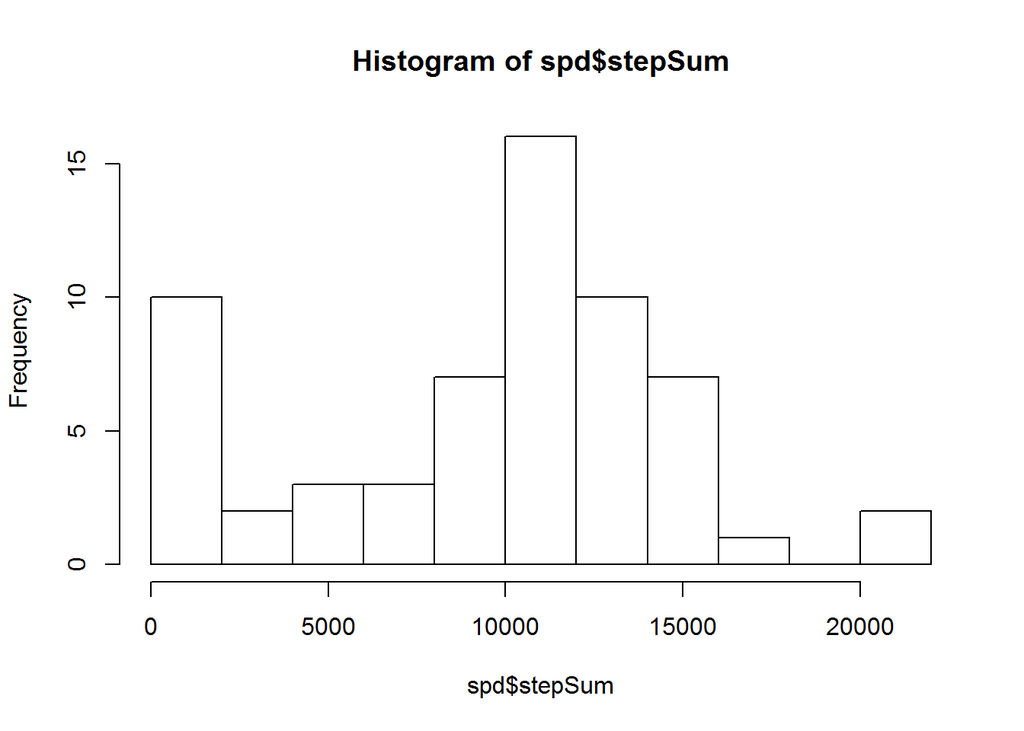

```r
hist (spd$stepSum, breaks=13)
```

What is the average daily activity pattern? To get this result Plyr applied as below: .

```r
spi <- ddply (acts,
              .(interval),
              summarize,
              stepMean = mean(steps, na.rm=TRUE))
```

The result is displayed below:

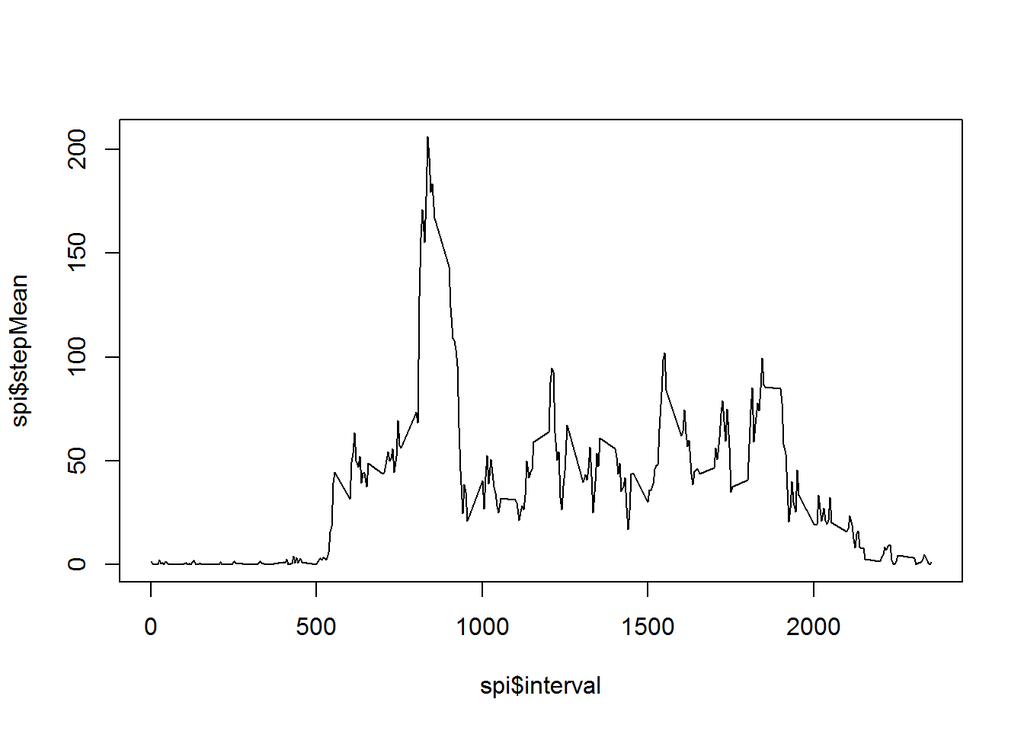

```r
plot (spi$interval, spi$stepMean, type='l')
```

The result indicates that the busiest interval of the subject’s day, on average was 835.

Imputing missing values

```r
which <- is.na (acts$steps)
```

The data set comprises many missing step count values: a total of 2304, or 13 percent of the total. A two-stage strategy is used for imputing missing values to the data. First stage, an NA at interval i is replaced with the mean number of steps in that interval over the rest of the data set. Unfortunately, many intervals are NA over the entire series; a grand mean is imputed over all non-NA data.

```r
fixie <- acts
fixie$steps[which] <-
  spi$stepMean[spi$interval == fixie$interval[which]]
fixie$steps[is.na (fixie$steps)] <-
  mean (acts$steps, na.rm=TRUE)
```

To establish whether there is any change we look at the new histogram

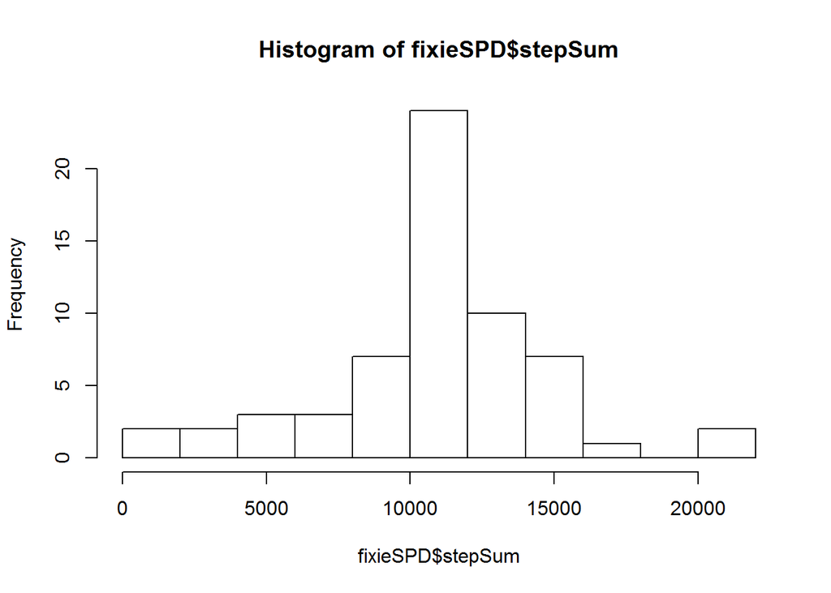

```r
fixieSPD <- ddply (fixie,
                   .(date),
                   summarize,
                   stepSum=sum (steps))
hist (fixieSPD$stepSum,
      breaks=13)
```

Are there differences in activity patterns between weekdays and weekends?

To establish this we, need to distinguish weekdays from weekends,which we do by the following:

```r
wd <- weekdays (as.Date (fixie$date))
fixie$dayTypes <- factor (wd,
                          levels <- c ('weekday', 'weekend'))
fixie$dayTypes[] <- 'weekday'
fixie$dayTypes[wd %in% c ('Saturday', 'Sunday')] <- 'weekend'
```

Next we compute summaries and plot comparing the two:

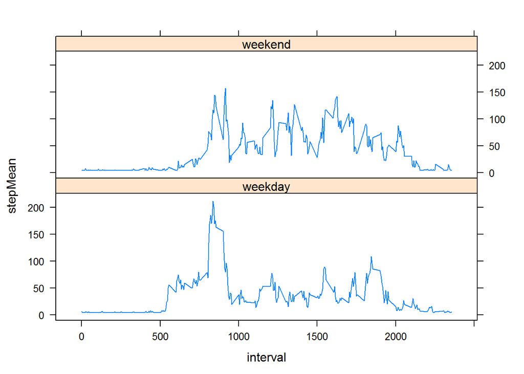

```r
spi <- ddply (fixie,
              .(interval, dayTypes),
              summarize,
              stepMean = mean(steps, na.rm=TRUE))
xyplot (stepMean ~ interval | dayTypes,
        data=spi,
        type='l',
        layout=c (1, 2))
```

In Conclusion The resulting plots show a difference between weekend and weekday activity patterns. On weekdays, the subject’s average level rises abruptly just before start of day. Activity levels then became moderate and later fall.

On the other hand, the weekday pattern is different. The general level of activity on a weekday is lower than for the same period of time on a weekend.